# “ggplot2”

### 4.Case Study

MAACS Cohort

- Mouse Allergen and Asthma Cohort Study
- Baltimore children (aged 5—17)
- Persistent asthma, exacerbation in past year
- Study indoor environment and its relationship with asthma morbidity

```r
# Load Data
load("C:/Users/admin/Documents/ExploratoryDataAnalysis/data/maacs.Rda")
str(maacs)
```

```
## 'data.frame':    750 obs. of  5 variables:
##  $ id       : int  1 2 3 4 5 6 7 8 9 10 ...
##  $ eno      : num  141 124 126 164 99 68 41 50 12 30 ...
##  $ duBedMusM: num  2423 2793 3055 775 1634 ...
##  $ pm25     : num  15.6 34.4 39 33.2 27.1 ...
##  $ mopos    : Factor w/ 2 levels "no","yes": 2 2 2 2 2 2 2 2 2 2 ...
```

#### 4.1 Histogram of eNo

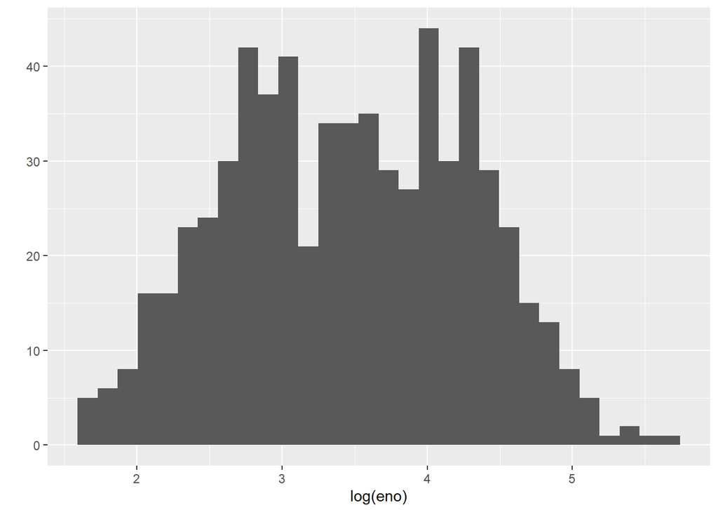

```r
qplot(log(eno),data = maacs)
```

#### 4.2 Histogram by Group

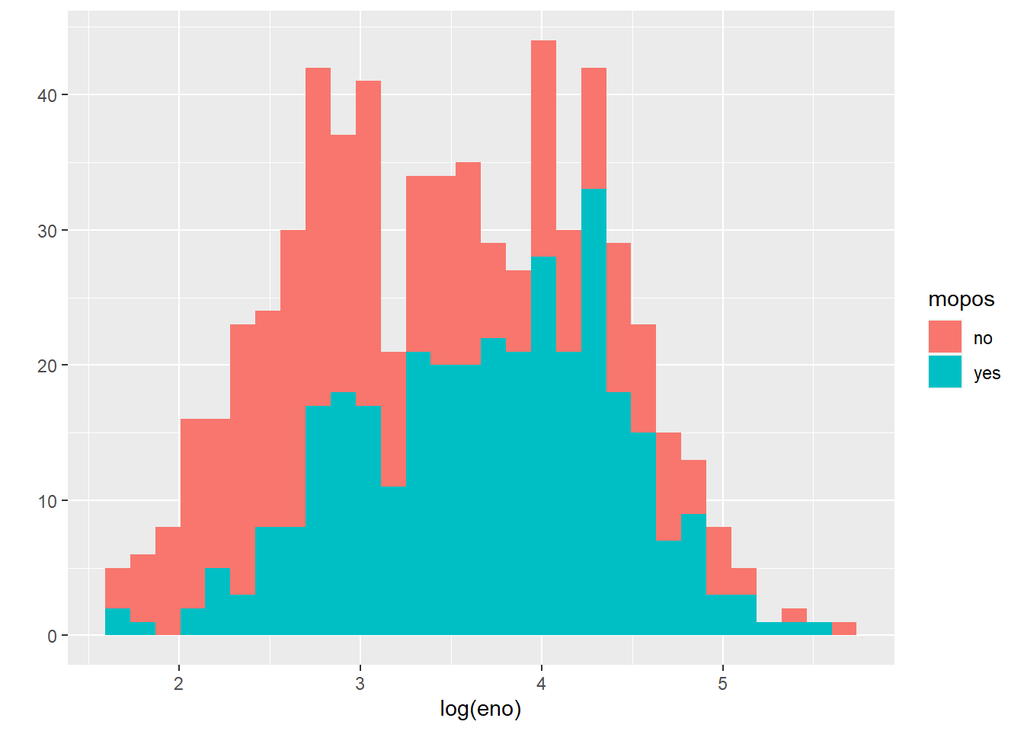

```r
qplot(log(eno),data = maacs,fill=mopos)
```

#### 4.3 Density Smooth

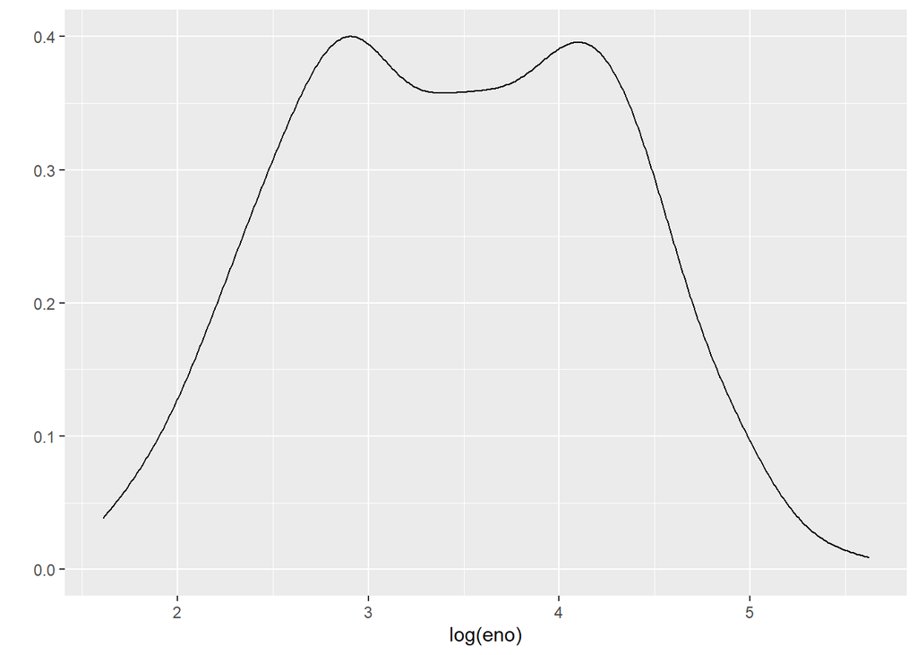

```r
qplot(log(eno),data = maacs,geom = "density")
```

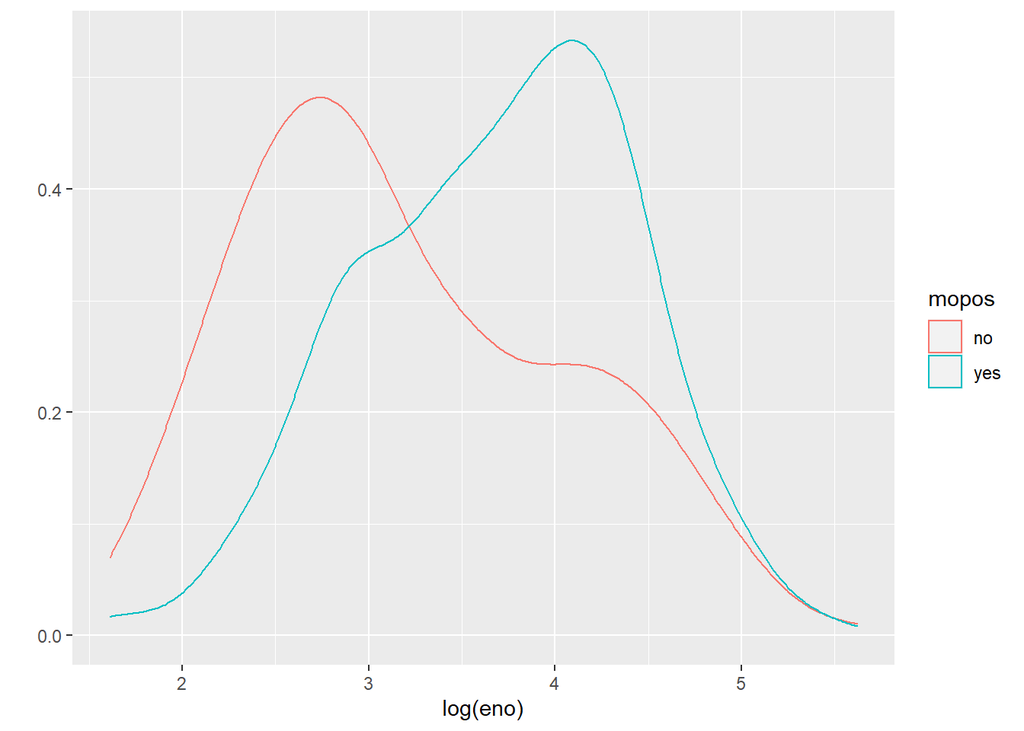

```r
qplot(log(eno),data = maacs,geom = "density",color=mopos)
```

#### 4.4 Scatterplots: $eNO$ vs. $PM_{2.5}$

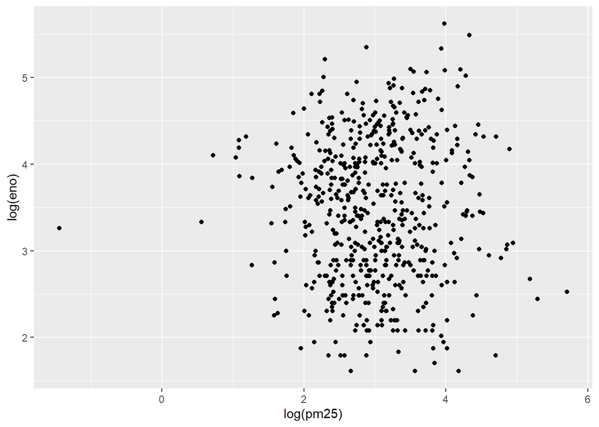

```r
qplot(log(pm25),log(eno),data = maacs)
```

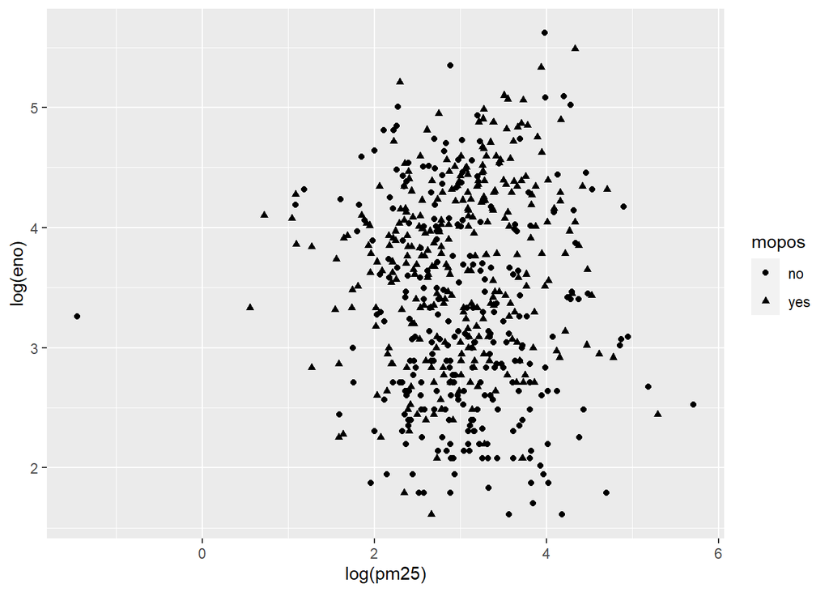

```r
qplot(log(pm25),log(eno),data = maacs,shape=mopos)
```

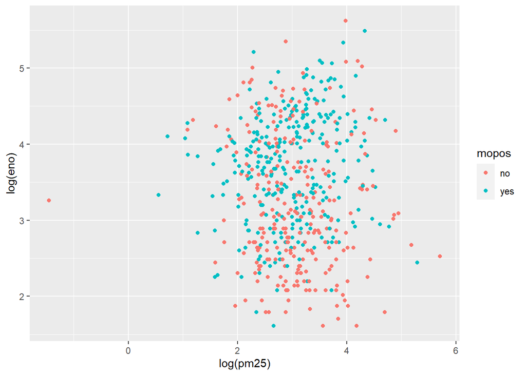

```r
qplot(log(pm25),log(eno),data = maacs,color=mopos)
```

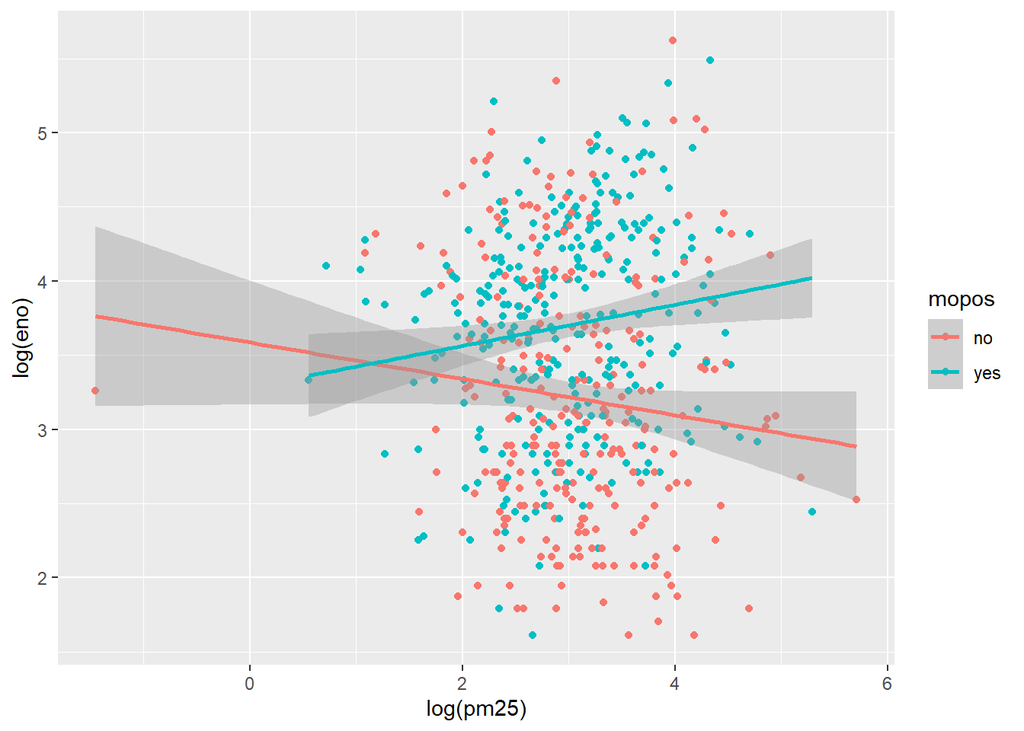

```r
qplot(log(pm25),log(eno),data = maacs,color=mopos,geom = c("point","smooth"),method="lm")
```

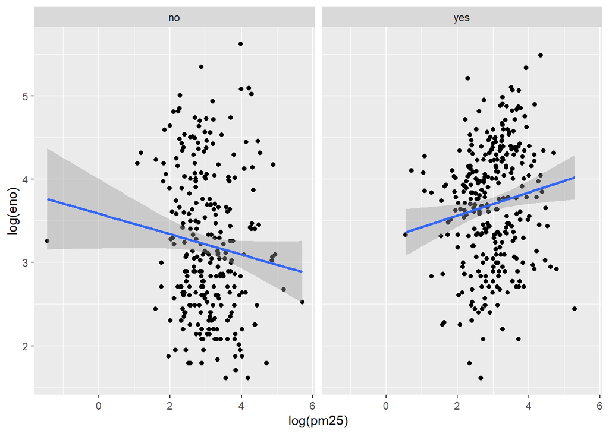

```r
qplot(log(pm25),log(eno),data = maacs,geom = c("point","smooth"),method="lm",facets =.~mopos)
```

### 5. Basic Components of a ‘ggplot2’ Plot

- A **data frame**
- **aesthetic mappings**: how data are mapped to *color, size*
- **geoms**: geometric objects like *points, lines, shapes*.
- **facets**: for *conditional plots*.
- **stats**: statistical transformations like *binning, quantiles, smoothing*.
- **scales**: what scale an aesthetic map uses (example: male = red, female = blue).
- **coordinate system**

### 6. Building Plots with ggplot2 (with Layers)

- When building plots in `ggplot2` (rather than using `qplot`) the “artist’s palette” model may be the closest analogy
- Plots are built up in layers  
  – Plot the data – Overlay a summary – Metadata and annotation

#### Example: BMI, PM<sub>2.5</sub>, Asthma

- Mouse Allergen and Asthma Cohort Study
- Baltimore children (age 5-17)
- Persistent asthma, exacerbation in past year
- Does BMI (normal vs. overweight) modify the relationship between PM<sub>2.5</sub> and asthma symptoms?

```r
url <- "https://raw.githubusercontent.com/rdpeng/artofdatascience/master/manuscript/data/bmi_pm25_no2_sim.csv"
download.file(url,"./data/maacs1.csv",method = "curl")
maacs1 <- read.csv("./data/maacs1.csv")
str(maacs1)
```

```
## 'data.frame':    517 obs. of  4 variables:
##  $ logpm25       : num  1.248 1.122 1.93 1.368 0.775 ...
##  $ logno2_new    : num  1.184 1.552 1.432 1.774 0.765 ...
##  $ bmicat        : chr  "normal weight" "overweight" "normal weight" "overweight" ...
##  $ NocturnalSympt: int  1 0 0 2 0 0 0 0 0 3 ...
```

```r
maacs1$bmicat<- factor(maacs1$bmicat)
str(maacs1)
```

```
## 'data.frame':    517 obs. of  4 variables:
##  $ logpm25       : num  1.248 1.122 1.93 1.368 0.775 ...
##  $ logno2_new    : num  1.184 1.552 1.432 1.774 0.765 ...
##  $ bmicat        : Factor w/ 2 levels "normal weight",..: 1 2 1 2 1 1 1 1 1 2 ...
##  $ NocturnalSympt: int  1 0 0 2 0 0 0 0 0 3 ...
```

#### 6.1 Basic Plot

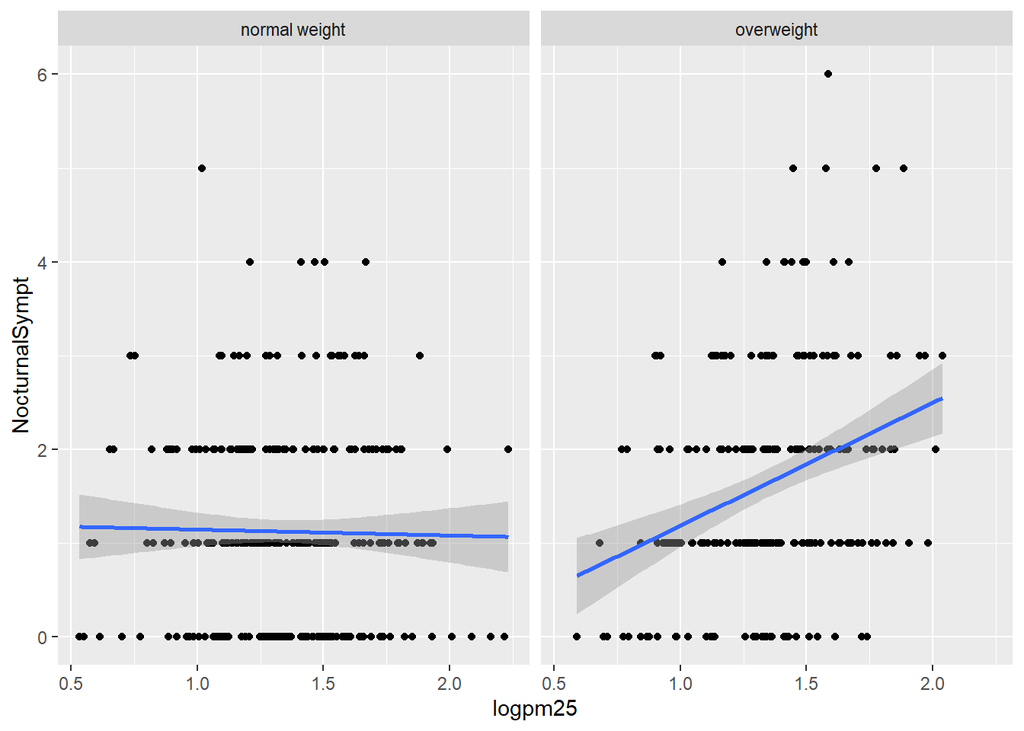

```r
qplot(logpm25,NocturnalSympt,data = maacs1,geom = c("point","smooth"),method="lm",facets=.~bmicat)
```

#### 6.2. Building Up in Layers

```r
# Initial call to ggplot
g <- ggplot(maacs1,aes(logpm25,NocturnalSympt))

# summary of ggplot
summary(g)
```

```
## data: logpm25, logno2_new, bmicat, NocturnalSympt [517x4]
## mapping:  x = ~logpm25, y = ~NocturnalSympt
## faceting: <ggproto object: Class FacetNull, Facet, gg>
##     compute_layout: function
##     draw_back: function
##     draw_front: function
##     draw_labels: function
##     draw_panels: function
##     finish_data: function
##     init_scales: function
##     map_data: function
##     params: list
##     setup_data: function
##     setup_params: function
##     shrink: TRUE
##     train_scales: function
##     vars: function
##     super:  <ggproto object: Class FacetNull, Facet, gg>
```

```r
print(g) # Errot: No layers in plot
```

#### First Plot with Point Layer

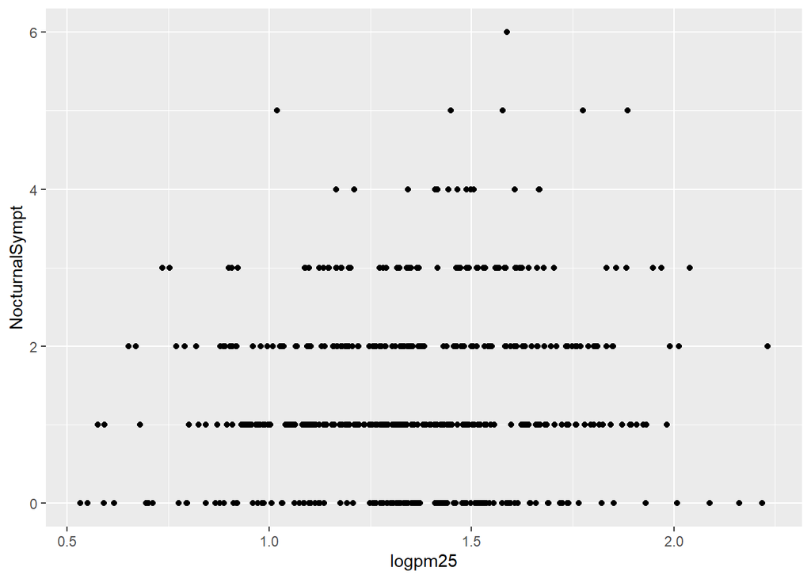

```r
p <- g + geom_point() # Explicitly save ggplot2 object
print(p) # Now able to print
```

#### 6.3. Adding More Layers: Smooth

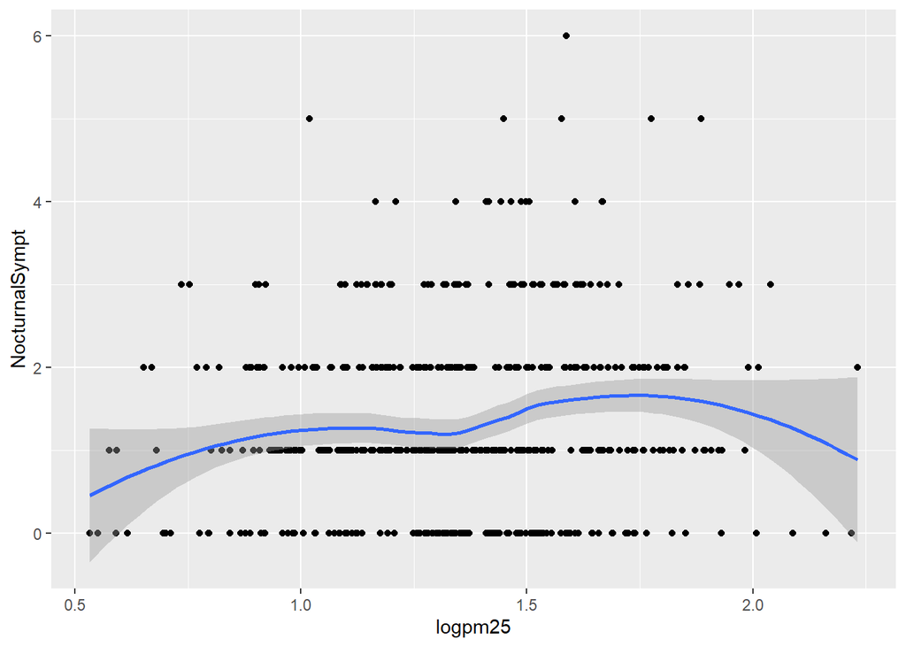

```r
g + geom_point() + geom_smooth()
```

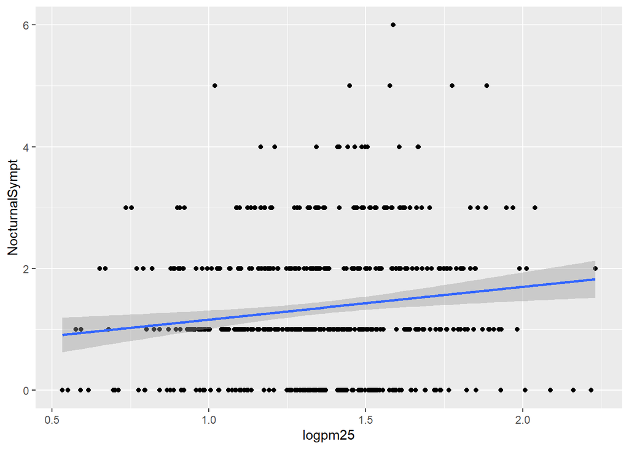

```r
g + geom_point() + geom_smooth(method = "lm")
```

#### 6.4. Adding More Layers: Facets

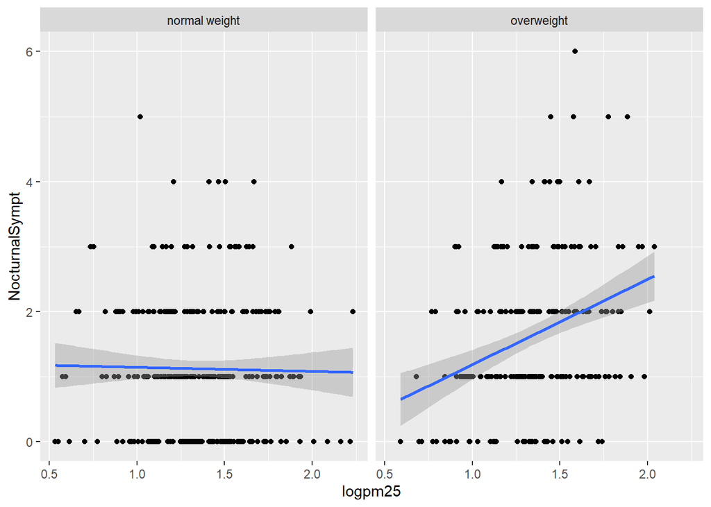

```r
g + geom_point() + geom_smooth(method = "lm") + facet_grid(.~bmicat)
```

### 7. Annotation

- Labels: `xlab()`, `ylab()`, `labs()`, `ggtitle()`
- Each of the “geom” functions has options to modify
- For things that only make sense globally, use `theme()`
  - Example: theme(legend.position = “none”)
- Two standard appearance themes are included
  - `theme_gray()`: The default theme (gray background)
  - `theme_bw()`: More stark/plain

### 8. Modifying Aesthetics

#### 8.1 Constant Variable

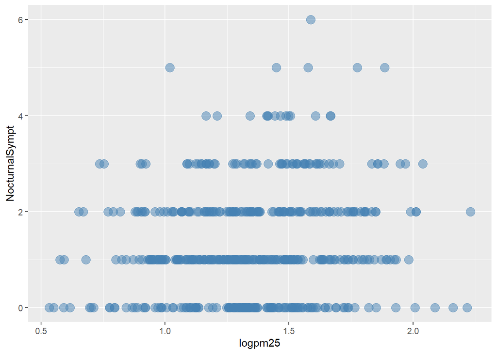

```r
g + geom_point(color = "steelblue", size = 4, alpha = 1/2)
```

#### 8.2 Data Variable

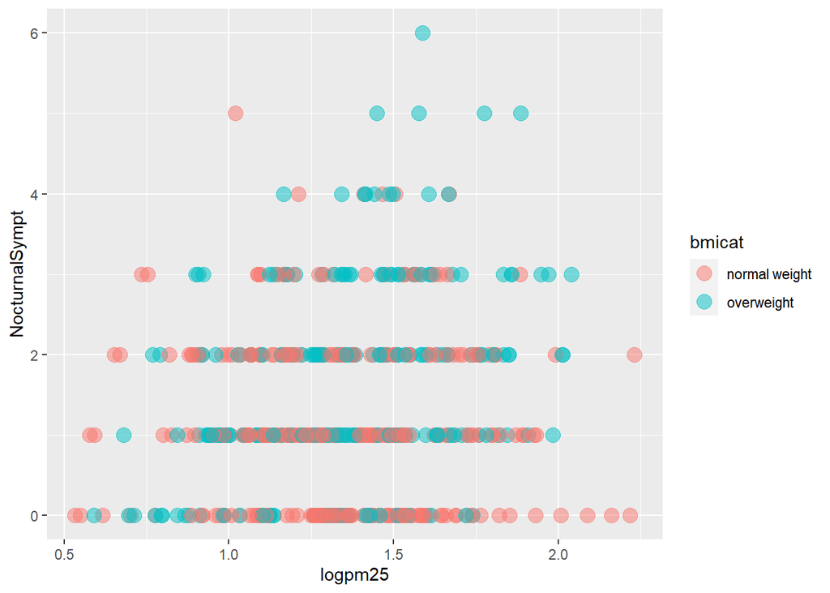

```r
g + geom_point(aes(color = bmicat), size = 4, alpha = 1/2)
```

### 8. Modifying Labels

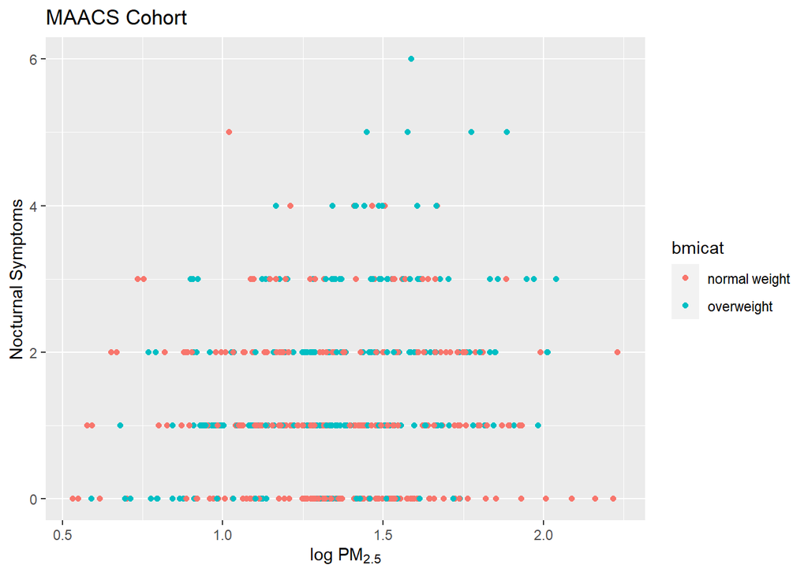

```r
g + geom_point(aes(color = bmicat)) + labs(title = "MAACS Cohort") + labs(x = expression("log "*PM[2.5]), y = "Nocturnal Symptoms")
```

### 9. Customizing the Smooth

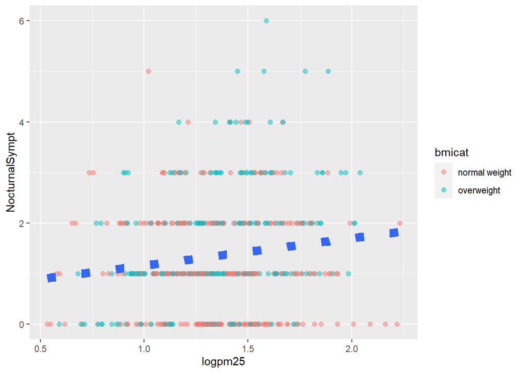

```r
g + geom_point(aes(color = bmicat), size = 2, alpha =1/2)+geom_smooth(size=4, linetype=3,method = "lm", se =FALSE)
```

### 10. Changing the Theme

```r
library(extrafont)
loadfonts(device = "win")
```

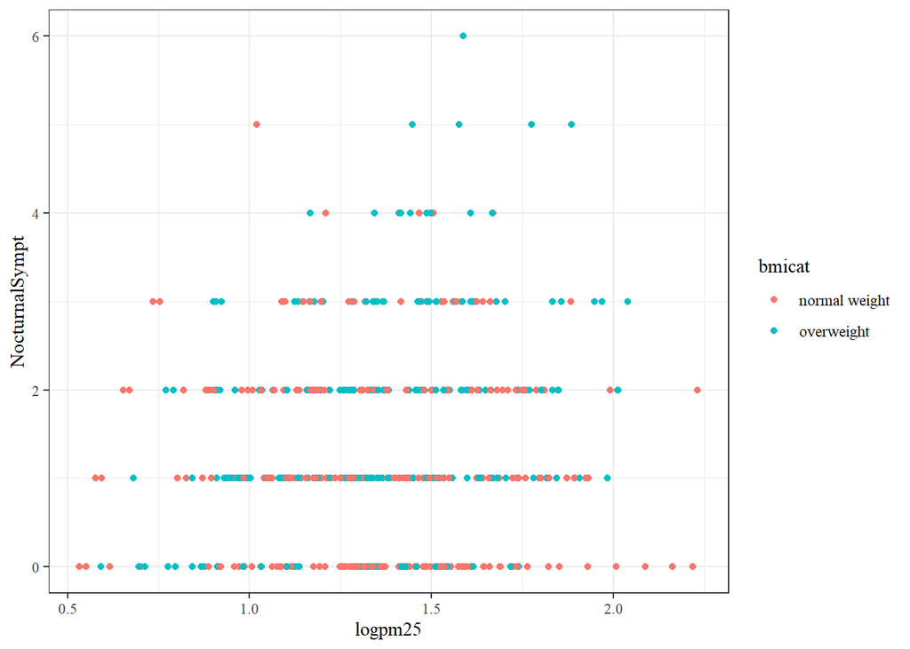

```r
g + geom_point(aes(color = bmicat)) + theme_bw(base_family = "Times New Roman")
```

#### if getting error “font family not found in Windows font database”

```r
install.packages("extrafont")
library(extrafont)
font_import()
loadfonts(device = "win")
```

### 11. About Access Limit

#### 11.1 Graph with outlier in base system

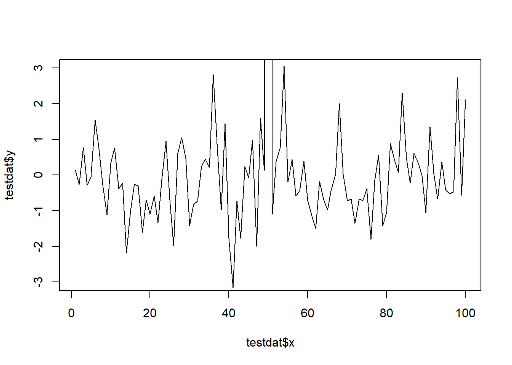

```r
testdat <- data.frame(x = 1:100, y = rnorm(100))
testdat[50,2] <- 100 ## Outlier!

plot(testdat$x, testdat$y, type = "l", ylim = c(-3,3))
```

#### 11.2 Graph with outlier in ggplot system (Default)

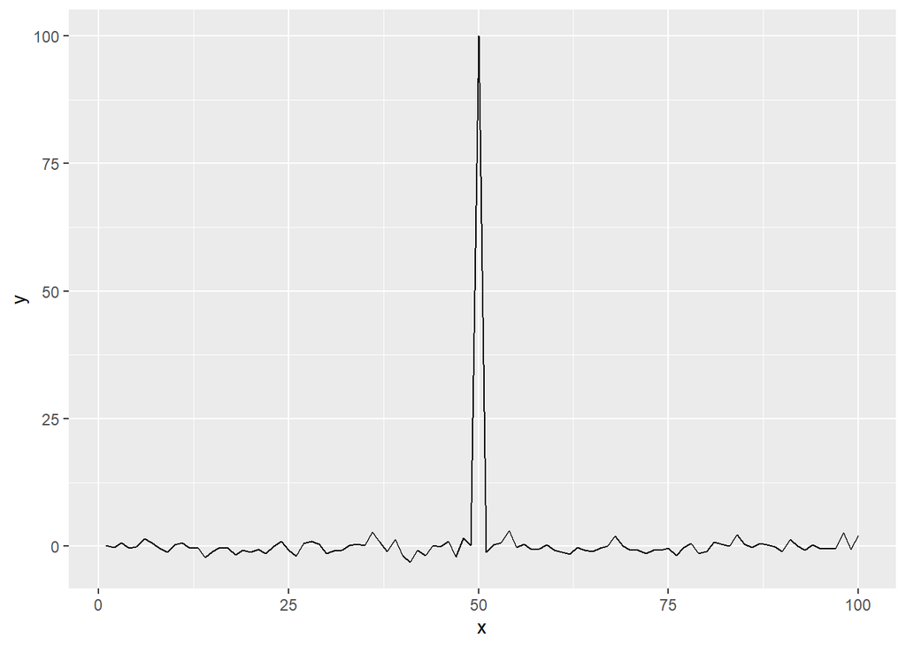

```r
g <- ggplot(testdat, aes(x=x,y=y))
g+geom_line()
```

#### 11.3 Graph with outlier in ggplot system (setting ylim (-3,3))

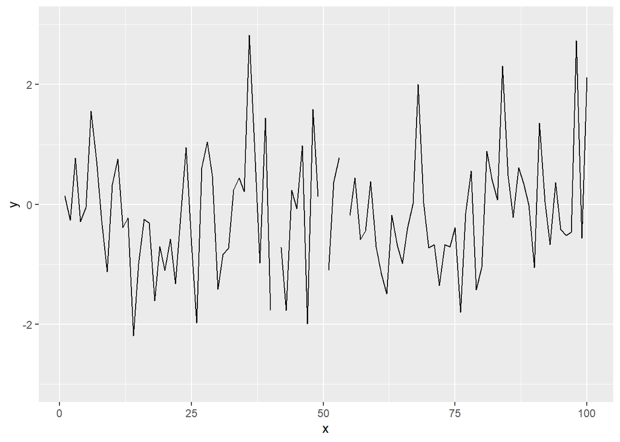

```r
g + geom_line() + ylim(-3,3)
```

#### 11.4 Graph with outlier in ggplot system (Optimized way)

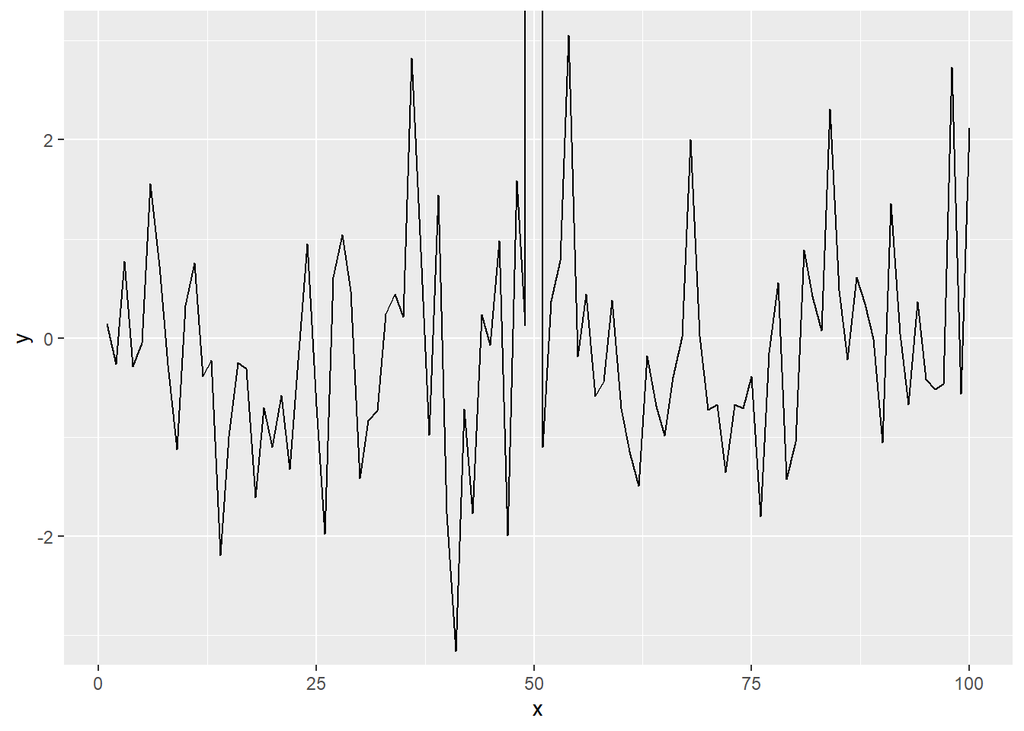

```r
g + geom_line() + coord_cartesian(ylim=c(-3,3))
```

- Unlike our previous BMI variable, NO<sub>2</sub> is continuous
- We need to make NO<sub>2</sub> categorical so we can condition on it in the plotting
  - Use the `cut()` function for this

```r
cutpoints <- quantile(maacs1$logno2_new,seq(0,1,length = 4),na.rm = TRUE)

print(cutpoints)
```

```
##        0% 33.33333% 66.66667%      100%
## 0.3419452 1.2286107 1.4679603 2.1695374
```

```r
maacs1$no2dec <- cut(maacs1$logno2_new,cutpoints)

print(head(maacs1$no2dec))
```

```
## [1] (0.342,1.23] (1.47,2.17]  (1.23,1.47]  (1.47,2.17]  (0.342,1.23]
## [6] (0.342,1.23]
## Levels: (0.342,1.23] (1.23,1.47] (1.47,2.17]
```

3. See the levels of the newly created factor variable

```r
levels(maacs1$no2dec)
```

```
## [1] "(0.342,1.23]" "(1.23,1.47]"  "(1.47,2.17]"
```

#### 12.2 Final Plot

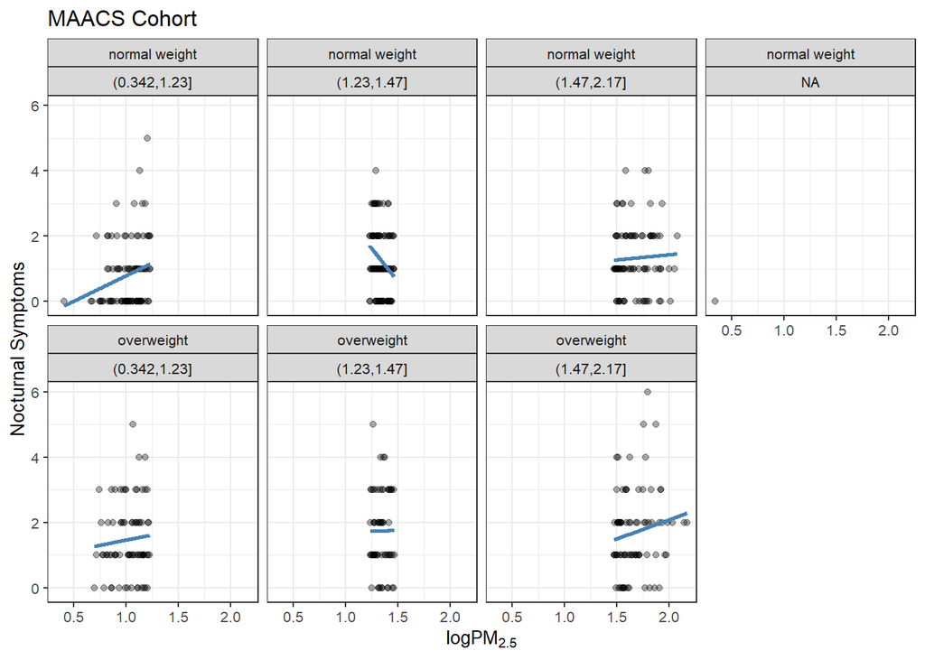

```r
library(extrafont)
loadfonts(device = "win")


g = ggplot(maacs1,aes(logno2_new,NocturnalSympt))

g + geom_point(alpha = 1/3)+ facet_wrap(bmicat ~ no2dec, nrow = 2, ncol =4)+ geom_smooth(method = "lm", se = FALSE, col= "steelblue")+ theme_bw(base_family = "Avenir", base_size = 10)+ labs(x = expression("log"*PM[2.5]), y = "Nocturnal Symptoms", title = "MAACS Cohort")
```